# S0 — Infrastruttura server, baseline riproducibile, design v1.1

geo_spatialtrans — report di step

Published

September 18, 2026

```r
.libPaths("~/2025.geo_spatialtrans/renv/library/linux-ubuntu-noble/R-4.6/x86_64-pc-linux-gnu")
suppressPackageStartupMessages({library(ggplot2); library(dplyr); library(Matrix)})
kable <- knitr::kable
theme_set(theme_bw(base_size = 11))
root <- normalizePath("..")
rd <- function(...) file.path(root, ...)
git_sha <- system(sprintf("git -C %s rev-parse --short HEAD", root), intern = TRUE)
git_branch <- system(sprintf("git -C %s rev-parse --abbrev-ref HEAD", root), intern = TRUE)
```

Sessione **S0** — 2026-09-18 — branch `step1-cell-layer` @ `7836829` (il commit di chiusura è quello indicato nella nota di sessione `docs/sessions/2026-09-18_S0.md`). Tutti i numeri di questo report sono letti dai file prodotti da `R/testing/run_S0.sh` (`results/S0_*.csv`, `logs/S0_*.log`); nessun valore è trascritto a mano.

# 1. Pre-registrazione

Attese scritte in chat prima di qualsiasi esecuzione; approvate da Luca il 2026-09-18 (“il resto ok”, con la sola correzione sul clone del Mac).

| Check | Attesa | Soglia / esito atteso | Fonte |
| --- | --- | --- | --- |
| C-S0.1 | Branch `step1-cell-layer` da `dev@7836829`; a fine sessione tree pulito, commit pushato | `git status` vuoto; `origin/step1-cell-layer` = HEAD | roadmap §5 |
| C-S0.2 | Libreria di progetto da Posit PPM: caricano con `Rscript --vanilla` + `.libPaths()` esplicito i 6 pacchetti Step 1 (sf, deldir, polylabelr, imager, testthat, quarto) + 29 dipendenze della pipeline | PASS = tutti caricano; WARN = ≥1 compilato da sorgente; FAIL = ≥1 non carica. `sf_extSoftVersion()` = GEOS 3.12.1 / GDAL 3.8.4 / PROJ 9.4.0 | procedura MMM |
| C-S0.3 | `Rscript --vanilla R/testing/full_test.R` (seed 42, config committata) termina con exit 0 sotto R 4.6.1 | 7/7 asserzioni interne PASS (soglie dello script: sparsità 30–92 %, UMI medio 3000–20000, CV 0.15–1.0, 8 cluster, nessun NA, Moran’s I > 0.05) | script committato |
| C-S0.4 | Due run indipendenti con seed 42 | uguaglianza esatta di n_cells, dim matrice, sparsità, UMI medio/mediano/CV e md5 della matrice di espressione salvata | design §6.2 |
| C-S0.5 | Confronto con gli RDS legacy: **pre-registrato come non riproducibile** | n_cells del run ≠ 180 000; config diversa; legacy conservati in `R/testing/legacy/` | analisi di provenienza (apertura S0) |
| C-S0.6 | Documenti: ROADMAP, CHANGELOG, BACKLOG, BIO_REFERENCES (solo schema), design v1.1, template report, S0.qmd → HTML, nota di sessione, `renv.lock` per R 4.6.1 | tutti presenti e versionati; `quarto render` exit 0 | skill/roadmap |
| Controprova 1 | seed 43 | n_cells/sparsità/checksum **diversi** dal run a seed 42 | — |
| Controprova 2 | script originale (`dev`) senza `.libPaths()` di progetto | **FAIL** su pacchetto mancante | — |

**Check B**: nessuno. S0 non contiene biologia; le soglie interne di `full_test.R` sono valori senza fonte (BACKLOG BL-002) e qui vengono solo *eseguite*, non validate.

**Aggiunta non pre-registrata (dichiarata)**: la libreria è stata costruita in tre passaggi di `tools/setup_r_library.R`: (1) i 35 pacchetti richiesti + dipendenze dichiarate da `install.packages` (127 pacchetti; 37 namespace restavano risolti dalla site-library di sistema); (2) installazione dei 37 namespace (164); (3) chiusura ricorsiva Depends/Imports/LinkingTo dal repository PPM (186), necessaria perché `renv/activate.R` isola la libreria e un namespace caricato pigramente (`labeling`) mancava. Tutti i check sono stati **rieseguiti dopo ogni passaggio**, più una quarta volta dopo la revisione avversariale (con `R_LIBS_SITE` e `R_LIBS_USER` puntati a directory inesistenti, vedi §2.1); i numeri del report si riferiscono all’**ultima esecuzione** (timestamp in `logs/S0_run_all.log`, riportati sotto). Il confronto dei md5 fra i passaggi è in §2.4 come osservazione, non come check approvato.

```r
cat(grep("^== ", readLines(rd("logs/S0_run_all.log")), value = TRUE), sep = "\n")
```

```
== 2026-09-18T13:52:10+02:00 test_S0_library
== 2026-09-18T13:52:13+02:00 full_test run1 (seed 42)
== 2026-09-18T13:53:53+02:00 full_test run2 (seed 42)
== 2026-09-18T13:55:33+02:00 full_test seed43 (controprova 1)
== 2026-09-18T13:57:08+02:00 controprova 2: script originale (dev) senza .libPaths() di progetto
== 2026-09-18T13:57:09+02:00 test_S0_baseline
== 2026-09-18T13:57:12+02:00 checksums (file tracciato: results/S0_checksums.md5)
== 2026-09-18T13:57:12+02:00 done
```

# 2. Check C — correttezza software

## 2.1 C-S0.2 — libreria R

```r
lib <- read.csv(rd("results/S0_library_check.csv"))
kable(lib %>% transmute(pacchetto = pkg, set, carica = ifelse(loads, "PASS", "FAIL"), versione = version,
                        libreria = ifelse(in_project_lib, "progetto", "sistema"), built = built_R))
```

| pacchetto | set | carica | versione | libreria | built |
| --- | --- | --- | --- | --- | --- |
| sf | step1 | PASS | 1.1.3 | progetto | R 4.6.0; x86_64-pc-linux-gnu; 2026-09-12 04:21:49 UTC; unix |
| deldir | step1 | PASS | 2.0.4 | progetto | R 4.6.0; x86_64-pc-linux-gnu; 2026-08-12 20:21:29 UTC; unix |
| polylabelr | step1 | PASS | 1.0.0 | progetto | R 4.6.0; x86_64-pc-linux-gnu; 2026-07-06 14:30:16 UTC; unix |
| imager | step1 | PASS | 1.0.8 | progetto | R 4.6.0; x86_64-pc-linux-gnu; 2026-07-06 13:12:31 UTC; unix |
| testthat | step1 | PASS | 3.3.2 | progetto | R 4.6.0; x86_64-pc-linux-gnu; 2026-04-24 03:02:07 UTC; unix |
| quarto | step1 | PASS | 1.5.1 | progetto | R 4.6.0; ; 2026-04-24 22:18:55 UTC; unix |
| Matrix | pipeline | PASS | 1.7.6 | progetto | R 4.6.0; x86_64-pc-linux-gnu; 2026-08-12 20:21:51 UTC; unix |
| ClusterR | pipeline | PASS | 1.3.7 | progetto | R 4.6.0; x86_64-pc-linux-gnu; 2026-09-09 09:31:43 UTC; unix |
| dplyr | pipeline | PASS | 1.2.1 | progetto | R 4.6.0; x86_64-pc-linux-gnu; 2026-08-12 20:22:54 UTC; unix |
| sp | pipeline | PASS | 2.2.3 | progetto | R 4.6.0; x86_64-pc-linux-gnu; 2026-08-12 20:21:49 UTC; unix |
| gstat | pipeline | PASS | 2.1.6 | progetto | R 4.6.0; x86_64-pc-linux-gnu; 2026-04-24 23:13:13 UTC; unix |
| png | pipeline | PASS | 0.1.9 | progetto | R 4.6.0; x86_64-pc-linux-gnu; 2026-08-12 20:21:34 UTC; unix |
| pbapply | pipeline | PASS | 1.7.5 | progetto | R 4.6.0; ; 2026-09-02 04:00:10 UTC; unix |
| future | pipeline | PASS | 1.75.0 | progetto | R 4.6.0; ; 2026-08-12 20:22:03 UTC; unix |
| future.apply | pipeline | PASS | 1.20.2 | progetto | R 4.6.0; ; 2026-08-12 20:22:17 UTC; unix |
| scales | pipeline | PASS | 1.4.0 | progetto | R 4.6.0; ; 2026-08-12 20:22:07 UTC; unix |
| RColorBrewer | pipeline | PASS | 1.1.3 | progetto | R 4.6.0; ; 2026-08-12 20:21:34 UTC; unix |
| ggplot2 | pipeline | PASS | 4.0.3 | progetto | R 4.6.0; ; 2026-08-12 20:22:35 UTC; unix |
| tidyr | pipeline | PASS | 1.3.2 | progetto | R 4.6.0; x86_64-pc-linux-gnu; 2026-08-12 20:23:24 UTC; unix |
| viridis | pipeline | PASS | 0.6.5 | progetto | R 4.6.0; ; 2026-08-12 20:23:08 UTC; unix |
| reshape2 | pipeline | PASS | 1.4.5 | progetto | R 4.6.0; x86_64-pc-linux-gnu; 2026-08-12 20:23:13 UTC; unix |
| hexbin | pipeline | PASS | 1.28.6 | progetto | R 4.6.0; x86_64-pc-linux-gnu; 2026-07-29 05:45:00 UTC; unix |
| gridExtra | pipeline | PASS | 2.3.1 | progetto | R 4.6.0; ; 2026-08-12 20:22:12 UTC; unix |
| pheatmap | pipeline | PASS | 1.0.13 | progetto | R 4.6.0; ; 2026-04-24 22:07:46 UTC; unix |
| spatstat | pipeline | PASS | 3.6.2 | progetto | R 4.6.0; ; 2026-08-01 05:09:13 UTC; unix |
| spdep | pipeline | PASS | 1.4.2 | progetto | R 4.6.0; x86_64-pc-linux-gnu; 2026-04-24 22:49:09 UTC; unix |
| fields | pipeline | PASS | 17.3 | progetto | R 4.6.0; x86_64-pc-linux-gnu; 2026-08-12 20:22:20 UTC; unix |
| MASS | pipeline | PASS | 7.3.66 | progetto | R 4.6.0; x86_64-pc-linux-gnu; 2026-08-12 20:21:31 UTC; unix |
| cluster | pipeline | PASS | 2.1.8.3 | progetto | R 4.6.0; x86_64-pc-linux-gnu; 2026-08-12 20:21:30 UTC; unix |
| tictoc | pipeline | PASS | 1.2.1 | progetto | R 4.6.0; ; 2026-04-24 01:53:01 UTC; unix |
| tidyverse | pipeline | PASS | 2.0.0 | progetto | R 4.6.0; ; 2026-08-12 20:27:55 UTC; unix |
| rmarkdown | pipeline | PASS | 2.32 | progetto | R 4.6.0; ; 2026-09-02 04:00:02 UTC; unix |
| knitr | pipeline | PASS | 1.52 | progetto | R 4.6.0; ; 2026-09-07 03:56:59 UTC; unix |
| withr | pipeline | PASS | 3.0.3 | progetto | R 4.6.0; ; 2026-08-12 20:21:40 UTC; unix |
| renv | pipeline | PASS | 1.2.4 | progetto | R 4.6.0; ; 2026-08-04 05:05:53 UTC; unix |

```r
ns <- read.csv(rd("results/S0_namespace_origin.csv"))
loglib <- readLines(rd("logs/S0_test_library.log"))
cat(grep("^\\[(PASS|FAIL)\\] C-S0.2 (sf|tutti|\\.libPaths)", loglib, value = TRUE), sep = "\n")
```

```
[PASS] C-S0.2 sf GEOS = 3.12.1 (atteso 3.12.1)
[PASS] C-S0.2 sf GDAL = 3.8.4 (atteso 3.8.4)
[PASS] C-S0.2 sf PROJ = 9.4.0 (atteso 9.4.0)
[PASS] C-S0.2 tutti i 35 pacchetti caricano (35/35)
[PASS] C-S0.2 .libPaths() contiene solo libreria di progetto + libreria base di R (isolamento; richiede R_LIBS_SITE e R_LIBS_USER inesistenti come in run_S0.sh)
```

```r
cat(grep("^\\[INFO\\] R ", loglib, value = TRUE), sep = "\n")
```

```
[INFO] R 4.6.1; .libPaths() = /home/user/2025.geo_spatialtrans/renv/library/linux-ubuntu-noble/R-4.6/x86_64-pc-linux-gnu | /usr/lib/R/library
```

```r
cat(sprintf("Namespace caricati (35 pacchetti + dipendenze non-base): %d, di cui dalla libreria di progetto: %d, dal sistema: %d\n",
            nrow(ns), sum(ns$lib == "project"), sum(ns$lib == "system")))
```

```
Namespace caricati (35 pacchetti + dipendenze non-base): 115, di cui dalla libreria di progetto: 115, dal sistema: 0
```

```r
setup1 <- readLines(rd("logs/S0_setup_r_library.log")); setup2 <- readLines(rd("logs/S0_setup_r_library_pass2.log")); setup3 <- readLines(rd("logs/S0_setup_r_library_pass3.log"))
n_lib <- length(list.dirs(rd("renv/library/linux-ubuntu-noble/R-4.6/x86_64-pc-linux-gnu"), recursive = FALSE))
cat(sprintf("Pacchetti nella libreria di progetto (directory): %d\n", n_lib))
```

```
Pacchetti nella libreria di progetto (directory): 186
```

```r
cat(sprintf("Installazioni da sorgente (passi 1/2/3): %d / %d / %d; da binario: %d / %d / %d\n",
            sum(grepl("installing \\*source\\*", setup1)), sum(grepl("installing \\*source\\*", setup2)), sum(grepl("installing \\*source\\*", setup3)),
            sum(grepl("installing \\*binary\\*", setup1)), sum(grepl("installing \\*binary\\*", setup2)), sum(grepl("installing \\*binary\\*", setup3))))
```

```
Installazioni da sorgente (passi 1/2/3): 0 / 0 / 0; da binario: 127 / 37 / 22
```

## 2.2 C-S0.3 / C-S0.4 / C-S0.5 — baseline `full_test.R`

```r
bc <- read.csv(rd("results/S0_baseline_check.csv"))
kable(bc)
```

| check | esito | dettaglio |
| --- | --- | --- |
| C-S0.3 run1 status | PASS | status=PASS, seed=42 |
| C-S0.3 run2 status | PASS | status=PASS, seed=42 |
| C-S0.4 n_cells_generated | PASS | run1=20000 \| run2=20000 |
| C-S0.4 n_clusters_found | PASS | run1=8 \| run2=8 |
| C-S0.4 matrix_dims | PASS | run1=5000x20000 \| run2=5000x20000 |
| C-S0.4 sparsity_pct | PASS | run1=90 \| run2=90 |
| C-S0.4 umi_mean | PASS | run1=8766 \| run2=8766 |
| C-S0.4 umi_median | PASS | run1=6850 \| run2=6850 |
| C-S0.4 umi_cv | PASS | run1=0.885 \| run2=0.885 |
| C-S0.4 md5 full_simulation_data run1==run2 | PASS | 5e3ba1f694fe947aee9de32b9b6c82b1 \| 5e3ba1f694fe947aee9de32b9b6c82b1 |
| C-S0.4 identical(expression) run1==run2 | PASS | dim=5000x20000, nnz=10005496 |
| C-S0.4 identical(coordinates) run1==run2 | PASS | n=20000 |
| Controprova-1 seed43: status PASS | PASS | status=PASS, seed=43 |
| Controprova-1 seed43: md5 diverso da run1 | PASS | 3cc7e8ca524422c9bb7bb451c0ba5639 vs 5e3ba1f694fe947aee9de32b9b6c82b1 |
| Controprova-1 seed43: expression diversa da run1 | PASS | n_cells run1=20000 seed43=20000; sparsita run1=90.0 seed43=89.5; umi_mean run1=8766 seed43=9149 |
| C-S0.5 legacy n_cells != run1 n_cells (atteso diverso) | PASS | legacy=180000 (cfg n_cells=90000, px=2.5, grid=6.5 mm) vs run1=20000 (cfg n_cells=10000, px=10, grid=8 mm) |
| C-S0.5 legacy full_simulation_data seed != 42 (atteso 1200) | PASS | seed legacy=1200 |

```r
rs <- read.csv(rd("results/S0_runs_summary.csv"))
kable(rs, caption = "Riassunto dei run (S0_run1/S0_run2 = seed 42 con la config committata; S0_seed43 = controprova 1; legacy_visHD = RDS legacy prodotto da full_test_visHD.R)")
```

Riassunto dei run (S0_run1/S0_run2 = seed 42 con la config committata; S0_seed43 = controprova 1; legacy_visHD = RDS legacy prodotto da full_test_visHD.R)

| run | seed | n_cells | sparsity_pct | umi_mean | umi_median | umi_cv | elapsed_min | md5_data |
| --- | --- | --- | --- | --- | --- | --- | --- | --- |
| S0_run1 | 42 | 20000 | 90.0 | 8766 | 6850 | 0.885 | 1.56 | 5e3ba1f694fe947aee9de32b9b6c82b1 |
| S0_run2 | 42 | 20000 | 90.0 | 8766 | 6850 | 0.885 | 1.58 | 5e3ba1f694fe947aee9de32b9b6c82b1 |
| S0_seed43 | 43 | 20000 | 89.5 | 9149 | 7200 | 0.873 | 1.47 | 3cc7e8ca524422c9bb7bb451c0ba5639 |
| legacy_visHD | 42 | 180000 | 86.8 | 9343 | 7452 | 0.847 | 5.21 | NA |

Note (rilievi del revisore): (i) la riproducibilità di C-S0.4 è **identità della matrice di espressione e delle coordinate** (`identical()` e md5 di `results/full_simulation_data_*.rds`), non identità byte-a-byte dei file `full_test_result_*.rds`, che contengono un timestamp; (ii) le mediane UMI grezze sono 6849.5 (seed 42) e 7200.5 (seed 43): lo script le arrotonda con `round()` (half-to-even) a 6850 e 7200. I checksum sono registrati anche nel file tracciato `results/S0_checksums.md5`.

```r
cat(sprintf("mediana UMI grezza: seed 42 = %.1f; seed 43 = %.1f\n", median(Matrix::colSums(readRDS(rd("results/full_simulation_data_S0_run1.rds"))$expression)), median(Matrix::colSums(readRDS(rd("results/full_simulation_data_S0_seed43.rds"))$expression))))
```

```
mediana UMI grezza: seed 42 = 6849.5; seed 43 = 7200.5
```

```r
cat(readLines(rd("results/S0_checksums.md5")), sep = "\n")
```

```
5e3ba1f694fe947aee9de32b9b6c82b1  results/full_simulation_data_S0_run1.rds
5e3ba1f694fe947aee9de32b9b6c82b1  results/full_simulation_data_S0_run2.rds
3cc7e8ca524422c9bb7bb451c0ba5639  results/full_simulation_data_S0_seed43.rds
5e3ba1f694fe947aee9de32b9b6c82b1  results/full_simulation_data_S0.rds
```

Asserzioni interne di `full_test.R` per run (dal log):

```r
for (t in c("run1", "run2", "seed43")) {
  lg <- readLines(rd(sprintf("logs/S0_full_test_%s.log", t)))
  cat("==", t, "\n"); cat(grep("PASS|FAIL|Tempo totale", lg, value = TRUE), sep = "\n")
}
```

```
== run1
✓ Dimensioni matrice: PASS ( 5000 x 20000 )
✓ Sparsità: 90 % - PASS
✓ UMI medio: 8766 mediano: 6850 - PASS
✓ UMI CV: 0.89 - PASS
✓ Cluster assegnati: 8 / 8 - PASS
✓ Integrità dati: PASS
✓ Moran's I: 0.574 - PASS
Tempo totale: 1.56 minuti
RISULTATO COMPLESSIVO: ✓ PASS
== run2
✓ Dimensioni matrice: PASS ( 5000 x 20000 )
✓ Sparsità: 90 % - PASS
✓ UMI medio: 8766 mediano: 6850 - PASS
✓ UMI CV: 0.89 - PASS
✓ Cluster assegnati: 8 / 8 - PASS
✓ Integrità dati: PASS
✓ Moran's I: 0.574 - PASS
Tempo totale: 1.58 minuti
RISULTATO COMPLESSIVO: ✓ PASS
== seed43
✓ Dimensioni matrice: PASS ( 5000 x 20000 )
✓ Sparsità: 89.5 % - PASS
✓ UMI medio: 9149 mediano: 7200 - PASS
✓ UMI CV: 0.87 - PASS
✓ Cluster assegnati: 8 / 8 - PASS
✓ Integrità dati: PASS
✓ Moran's I: 0.444 - PASS
Tempo totale: 1.47 minuti
RISULTATO COMPLESSIVO: ✓ PASS
```

## 2.3 Osservazioni sulla pipeline attuale emerse dai log (non check, vanno in BACKLOG)

```r
lg <- readLines(rd("logs/S0_full_test_run1.log"))
cat(grep("Celle target|Griglia high-density|Sub-sampled|FILTRO HARD|UMI < 1", lg, value = TRUE), sep = "\n")
```

```
- Celle target: 10000
✓ Griglia high-density creata: 40000 celle
✓ Sub-sampled to: 20000 celle per performance
FILTRO HARD: 13 celle con >50k UMI sono state azzerate post-validazione
ATTENZIONE: Celle con UMI < 1 prima dello scaling: 1
FILTRO HARD: 16 celle con >50k UMI sono state azzerate post-validazione
FILTRO HARD: 16 celle con >50k UMI sono state azzerate post-validazione
FILTRO HARD: 10 celle con >50k UMI sono state azzerate post-validazione
FILTRO HARD: 13 celle con >50k UMI sono state azzerate post-validazione
FILTRO HARD: 21 celle con >50k UMI sono state azzerate post-validazione
FILTRO HARD: 16 celle con >50k UMI sono state azzerate post-validazione
FILTRO HARD: 16 celle con >50k UMI sono state azzerate post-validazione
FILTRO HARD: 21 celle con >50k UMI sono state azzerate post-validazione
FILTRO HARD: 12 celle con >50k UMI sono state azzerate post-validazione
```

- La config chiede `n_cells = 10000`, la griglia ne produce 40 000 e la pipeline ne sotto-campiona 20 000 “per performance”: il parametro `n_cells` **non** controlla il numero di celle generate (BL-010).
- Un “FILTRO HARD” azzera le celle con > 50 000 UMI dopo la validazione: un troncamento non documentato della coda della library size (BL-011).

## 2.4 Osservazione: effetto delle sotto-dipendenze sul risultato

```r
rs1 <- read.csv(rd("results/S0_runs_summary_pass1.csv")); rs2 <- read.csv(rd("results/S0_runs_summary_pass2.csv"))
cmp <- data.frame(run = rs$run, md5_pass1 = rs1$md5_data[match(rs$run, rs1$run)], md5_pass2 = rs2$md5_data[match(rs$run, rs2$run)], md5_pass3 = rs$md5_data)
cmp$identici <- ifelse(is.na(cmp$md5_pass1), NA, cmp$md5_pass1 == cmp$md5_pass2 & cmp$md5_pass2 == cmp$md5_pass3)
kable(cmp, caption = "md5 di results/full_simulation_data_<tag>.rds nei tre passaggi di costruzione della libreria (127 → 164 → 186 pacchetti)")
```

md5 di results/full_simulation_data_.rds nei tre passaggi di costruzione della libreria (127 → 164 → 186 pacchetti)

| run | md5_pass1 | md5_pass2 | md5_pass3 | identici |
| --- | --- | --- | --- | --- |
| S0_run1 | 5e3ba1f694fe947aee9de32b9b6c82b1 | 5e3ba1f694fe947aee9de32b9b6c82b1 | 5e3ba1f694fe947aee9de32b9b6c82b1 | TRUE |
| S0_run2 | 5e3ba1f694fe947aee9de32b9b6c82b1 | 5e3ba1f694fe947aee9de32b9b6c82b1 | 5e3ba1f694fe947aee9de32b9b6c82b1 | TRUE |
| S0_seed43 | 3cc7e8ca524422c9bb7bb451c0ba5639 | 3cc7e8ca524422c9bb7bb451c0ba5639 | 3cc7e8ca524422c9bb7bb451c0ba5639 | TRUE |
| legacy_visHD | NA | NA | NA | NA |

## 2.5 Figura — library size per cella, seed 42 vs seed 43

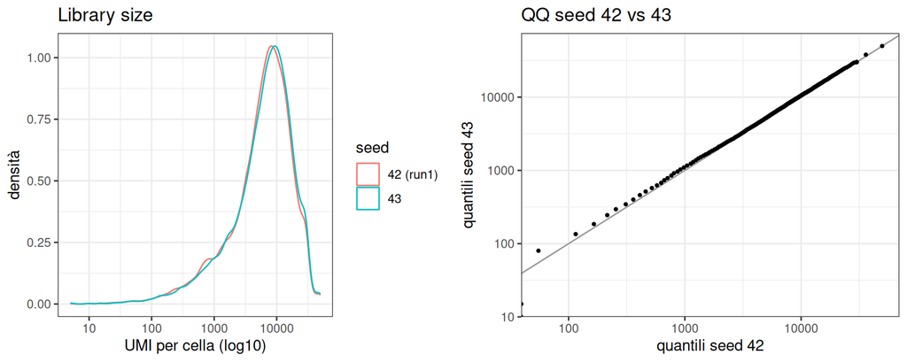

```r
d1 <- readRDS(rd("results/full_simulation_data_S0_run1.rds")); d3 <- readRDS(rd("results/full_simulation_data_S0_seed43.rds"))
umi <- bind_rows(data.frame(seed = "42 (run1)", umi = Matrix::colSums(d1$expression)),
                 data.frame(seed = "43", umi = Matrix::colSums(d3$expression)))
p1 <- ggplot(umi, aes(umi, colour = seed)) + geom_density() + scale_x_log10() + labs(x = "UMI per cella (log10)", y = "densità", title = "Library size")
qq <- data.frame(q42 = quantile(umi$umi[umi$seed != "43"], ppoints(200)), q43 = quantile(umi$umi[umi$seed == "43"], ppoints(200)))
p2 <- ggplot(qq, aes(q42, q43)) + geom_abline(slope = 1, intercept = 0, colour = "grey60") + geom_point(size = 0.8) + scale_x_log10() + scale_y_log10() + labs(x = "quantili seed 42", y = "quantili seed 43", title = "QQ seed 42 vs 43")
gridExtra::grid.arrange(p1, p2, ncol = 2)
```

# 3. Check B — plausibilità biologica (A1–A6)

Nessuno per S0 (dichiarato in pre-registrazione). Il primo check B arriva con S1.2 e richiede R1–R2.

# 4. Controprova

```r
cat(grep("Controprova-1", readLines(rd("logs/S0_test_baseline.log")), value = TRUE), sep = "\n")
```

```
[PASS] Controprova-1 seed43: status PASS — status=PASS, seed=43
[PASS] Controprova-1 seed43: md5 diverso da run1 — 3cc7e8ca524422c9bb7bb451c0ba5639 vs 5e3ba1f694fe947aee9de32b9b6c82b1
[PASS] Controprova-1 seed43: expression diversa da run1 — n_cells run1=20000 seed43=20000; sparsita run1=90.0 seed43=89.5; umi_mean run1=8766 seed43=9149
```

```r
c2 <- readLines(rd("logs/S0_controprova2_nolib.log"))
cat("\nControprova 2 (script dev originale, senza .libPaths() di progetto):\n")
```

```
Controprova 2 (script dev originale, senza .libPaths() di progetto):
```

```r
cat(grep("MISSING|Error|exit=", c2, value = TRUE), sep = "\n")
```

```
✗ MISSING: ClusterR
Error: Required library missing: ClusterR
exit=1
```

Interpretazione: (1) con seed 43 la matrice di espressione cambia (md5 e riassunti diversi) mentre n_cells resta 20 000 perché il numero di celle è fissato dalla griglia, non dal seed — la riproducibilità di C-S0.4 non è vacua. (2) Senza la libreria di progetto lo script si ferma su `ClusterR` mancante: la libreria verificata in C-S0.2 è quella effettivamente in uso.

# Verdetto

```r
n_fail <- sum(bc$esito == "FAIL") + sum(!lib$loads)
cat(sprintf("Check C: %d asserzioni baseline, %d FAIL; libreria: %d/%d pacchetti caricano.\n", nrow(bc), sum(bc$esito == "FAIL"), sum(lib$loads), nrow(lib)))
```

```
Check C: 17 asserzioni baseline, 0 FAIL; libreria: 35/35 pacchetti caricano.
```

- Stato: **chiuso con riserve** (la valutazione finale è nella nota di sessione, dopo la revisione avversariale).
- Riserve: (a) `renv.lock` rigenerato ma `renv::restore()` da macchina pulita non testato (BL-008); (b) il baseline certifica solo che la pipeline *gira ed è riproducibile*, non che sia biologicamente sensata (BL-002, BL-010, BL-011); (c) i parametri dei preset A4–A6 nel design v1.1 sono ipotesi senza fonte (BL-007).

# Revisione avversariale

Revisore indipendente (sotto-agente senza accesso a questo report, sola lettura sul server) ha ricalcolato dai file primari (RDS, libreria, git, log) 10 affermazioni: md5 delle matrici, riassunti e ricalcolo diretto da `colSums`, legacy, libreria (186 pacchetti, 35 caricano, versioni, GEOS/GDAL/PROJ), `renv.lock`, stato git, contenuto del design v1.1, controprova 2 rieseguita in proprio, osservazioni dai log. **Esito: 10/10 confermate, nessuna discrepanza numerica.** Rilievi non bloccanti accolti prima del commit: isolamento della libreria reso esplicito (`R_LIBS_SITE` e `R_LIBS_USER` inesistenti in `run_S0.sh` — la libreria utente `~/R/.../4.6` contiene 65 pacchetti — e asserzione dedicata in `test_S0_library.R`: `.libPaths()` = libreria di progetto + libreria base); checksum in file tracciato (`results/S0_checksums.md5`); note su passate, mediane `.5` e significato di “riproducibile” in §1–2. Rilievi rinviati a BACKLOG: `full_test.R` sovrascrive il PNG versionato `R/testing/full_tissue_complex.png` (BL-013); comportamento di sessioni R non `--vanilla` con il nuovo `.Rprofile` (documentato in ROADMAP §5).

# Riproducibilità

```bash
cd ~/2025.geo_spatialtrans && git checkout step1-cell-layer
bash R/testing/run_S0.sh          # ~7 min: libreria, 3 run di full_test.R, controprove, confronto
quarto render reports/S0.qmd   # .Rprofile (S0) punta renv alla libreria di progetto
```